# Lab 2-Metrics_feta

## 2. Primeres Mètriques i Evaluació de Models

En aquesta pràctica entendrem i observarem la importancia que té evaluar i seleccionar mètodes de evaluacions acurats per a definir si el nostre model està funcionant tal i com esperem.

Les mètriques d'avaluació són específiques del tipus de tasca d'aprenentatge automàtic que realitza un model.

Per exemple, per a la tasca de classificació, el model s'avalua mesurant el grau de coincidència d'una categoria predita amb la categoria real. I, per a l'agrupació en clústers, l'avaluació es basa en el pròxims que estan els uns dels altres els elements agrupats i en el grau de separació existent entre els clústers.

En aquesta pràctica treballarem sobre un cas molt senzill utilitzant un KNN, que ja haureu vist en diferents assigantures durant els cursos.

L'algorisme KNN és un classificador d'aprenentatge supervisat, que utilitza la proximitat per fer classificacions o prediccions sobre l'agrupació d'un punt de dades individual. És un dels classificadors més populars i més senzills que s'utilitzen actualment en l'aprenentatge automàtic.

#### Primerament definirem el model sobre un dataset ja definit en la propia llibreria del sklearn

més informació a: [https://scikit-learn.org/stable/datasets/toy_dataset.html]

```python
import matplotlib.pyplot as plt
import numpy as np
import pandas as pd
import seaborn as sns

from sklearn import datasets
from sklearn.model_selection import train_test_split , KFold
from sklearn.preprocessing import Normalizer, StandardScaler
from sklearn.metrics import accuracy_score, confusion_matrix, recall_score, precision_score, roc_curve, roc_auc_score
from sklearn.neighbors import KNeighborsClassifier
```

```python
# import iris dataset
iris = datasets.load_iris()
iris_df = pd.DataFrame(data= np.c_[iris['data'], iris['target']], columns= iris['feature_names'] + ['target'])
```

[figure not shown]

#### Extreiem dades i etiquetes (X i y)

```python
X= iris_df.iloc[:, :-1]
y= iris_df.iloc[:, -1]
```

```python
X.head()
```

|  | sepal length (cm) | sepal width (cm) | petal length (cm) | petal width (cm) |
| --- | --- | --- | --- | --- |
| 0 | 5.1 | 3.5 | 1.4 | 0.2 |
| 1 | 4.9 | 3.0 | 1.4 | 0.2 |
| 2 | 4.7 | 3.2 | 1.3 | 0.2 |
| 3 | 4.6 | 3.1 | 1.5 | 0.2 |
| 4 | 5.0 | 3.6 | 1.4 | 0.2 |

```python
print(y)
```

```
0      0.0
1      0.0
2      0.0
3      0.0
4      0.0
      ...
145    2.0
146    2.0
147    2.0
148    2.0
149    2.0
Name: target, Length: 150, dtype: float64
```

#### Definim el train i el test per al model

aprofitem per transformar-ho a format numpy

```python
x_train, x_test, y_train, y_test= train_test_split(X, y, test_size= 0.2, shuffle= True, random_state= 0)
x_train= np.asarray(x_train)
y_train= np.asarray(y_train)

x_test= np.asarray(x_test)
y_test= np.asarray(y_test)
```

```python
print(f'training set size: {x_train.shape[0]} samples \ntest set size: {x_test.shape[0]} samples')
```

```
training set size: 120 samples
test set size: 30 samples
```

#### Veiem les relacions entre variables

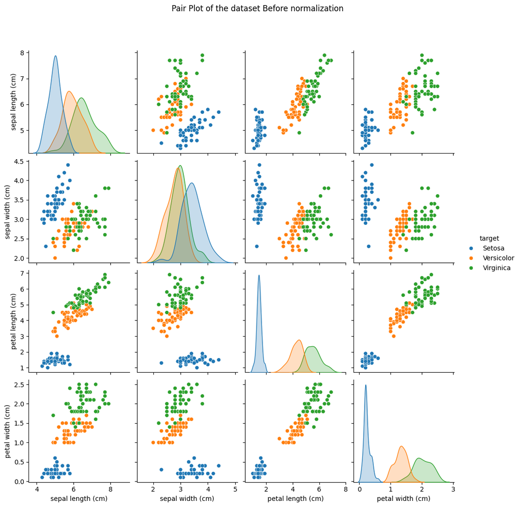

```python
di= {0.0: 'Setosa', 1.0: 'Versicolor', 2.0:'Virginica'} # dictionary

before= sns.pairplot(iris_df.replace({'target': di}), hue= 'target')
before.fig.suptitle('Pair Plot of the dataset Before normalization', y=1.08)
```

### Normalització i estandarització de les dades

En l’àmbit del machine learning i l’anàlisi de dades, la preparació adequada de les dades és un pas fonamental per millorar el rendiment dels models. Dos dels mètodes més utilitzats per a aquest propòsit són la normalització i l'estandarització. Aquests processos permeten ajustar els valors de les característiques (atributs) per fer que les diferents escales i rangs dels valors no afectin negativament els algorismes. Mentre que la normalització s’utilitza per ajustar la magnitud dels vectors de característiques, l'estandarització s’encarrega de centrar i escalar les dades de manera que tinguin una distribució coherent, facilitant així una millor convergència dels models i un rendiment més òptim en la classificació, regressió o altres tasques de predicció.

La normalització o estandarització de les dades és crucial en l’algorisme de K-Nearest Neighbors (KNN) perquè aquest algorisme es basa en el càlcul de distàncies per determinar la semblança entre les mostres. L'algorisme KNN classifica les mostres noves comparant-les amb les mostres existents del conjunt d'entrenament, utilitzant mesures de distància com la distància Euclidiana o la distància Manhattan. Això vol dir que KNN calcula distàncies entre els punts en funció dels valors de les característiques. Si les característiques tenen escales molt diferents (per exemple, si una característica va de 0 a 1000 i una altra de 0 a 10), la característica amb una escala més gran tindrà un impacte desproporcionat en el càlcul de la distància, dominant les altres característiques, encara que no sigui la més important per a la tasca de classificació.

Per a més informació en les diferents maneres de normalitzar les dades i els seus efectes podeu conultar: [https://scikit-learn.org/stable/modules/preprocessing.html#preprocessing]

### Normalització per norma

La **normalització per norma** és un procés en què els vectors de característiques es reescalen perquè la seva magnitud total sigui 1, mantenint les proporcions relatives entre les característiques.

Donat un vector de característiques $$ (\mathbf{x} = [x_1, x_2, ..., x_n]) $$ , la normalització per **norma L2** es calcula de la següent manera:

$$ \mathbf{x}' = \frac{\mathbf{x}}{||\mathbf{x}||_2} = \frac{\mathbf{x}}{\sqrt{x_1^2 + x_2^2 + \dots + x_n^2}} $$

```python
scaler = Normalizer().fit(x_train)
normalized_x_train= scaler.transform(x_train) # the scaler is applied to the training set
```

### Mai, mai mai

```python
scaler = Normalizer().fit(x_test)  # motiu per suspendre l'assignatura directament
normalized_x_test= scaler.transform(x_test) # the scaler is applied to the test set
```

```python
scaler = Normalizer().fit(x_train)
normalized_x_test= scaler.transform(x_test) # the scaler is applied to the test set
```

```python
print('x_train before Normalization')
print(x_train[0:5])
print('\nx_train after Normalization')
print(normalized_x_train[0:5])
```

```
x_train before Normalization
[[6.4 3.1 5.5 1.8]
 [5.4 3.  4.5 1.5]
 [5.2 3.5 1.5 0.2]
 [6.1 3.  4.9 1.8]
 [6.4 2.8 5.6 2.2]]

x_train after Normalization
[[0.69804799 0.338117   0.59988499 0.196326  ]
 [0.69333409 0.38518561 0.57777841 0.1925928 ]
 [0.80641965 0.54278246 0.23262105 0.03101614]
 [0.71171214 0.35002236 0.57170319 0.21001342]
 [0.69417747 0.30370264 0.60740528 0.2386235 ]]
```

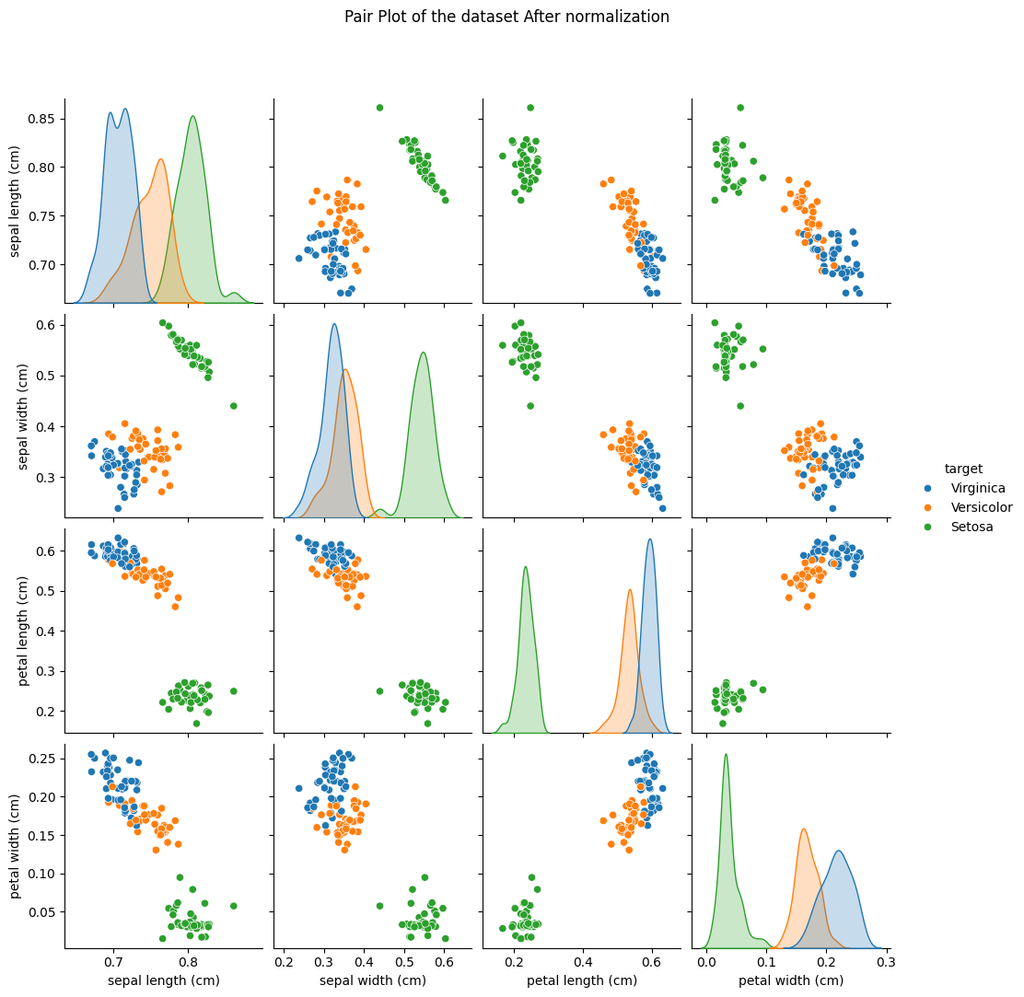

```python
iris_df_2= pd.DataFrame(data= np.c_[normalized_x_train, y_train], columns= iris['feature_names'] + ['target'])
di= {0.0: 'Setosa', 1.0: 'Versicolor', 2.0: 'Virginica'}
after= sns.pairplot(iris_df_2.replace({'target':di}), hue= 'target')
after.fig.suptitle('Pair Plot of the dataset After normalization', y=1.08)
```

#### Entrenament del model

```python
k=3
knn=KNeighborsClassifier(k)
knn.fit(normalized_x_train, y_train)
y_pred = knn.predict(normalized_x_test)
print(y_pred)
```

```
[2. 1. 0. 2. 0. 2. 0. 1. 1. 1. 2. 1. 1. 1. 1. 0. 1. 2. 0. 0. 2. 1. 0. 0.
 2. 0. 0. 1. 1. 0.]
```

```python
print(f'The accuracy of sklearn implementation is {accuracy_score(y_test, y_pred)}')
```

```
The accuracy of sklearn implementation is 0.9666666666666667
```

# Primeres mètriques

**En aquest exemple anem a provar amb un dataset binari anomenat Pima. El Pima Indians Diabetes Dataset és un conjunt de dades que conté informació mèdica de dones d'ascendència Pima, utilitzat freqüentment en machine learning per a problemes de classificació binària (diabetis o no diabetis). Els atributs inclouen valors numèrics com la glucosa, pressió arterial, índex de massa corporal, entre d'altres**

```python
from pandas import read_csv
# load the dataset
dataframe = read_csv("pima-indians-diabetes.csv", header=0, names=["Pregnancies", "Glucose", "Blood Preassure", "SkinThickness","Insulin", "BMI", "DiabetesPedigreeFunction","Age", "class"])
# get the values
values = dataframe.values
X, y = values[:, :-1], values[:, -1]
# gather details
n_rows = X.shape[0]
n_cols = X.shape[1]
classes = np.unique(y)
n_classes = len(classes)
# summarize
print('N Examples: %d' % n_rows)
print('N Inputs: %d' % n_cols)
print('N Classes: %d' % n_classes)
print('Classes: %s' % classes)
print('Class Breakdown:')
# class breakdown
breakdown = ''
for c in classes:
    total = len(y[y == c])
    ratio = (total / float(len(y))) * 100
    print(' - Class %s: %d (%.5f%%)' % (str(c), total, ratio))
```

```
N Examples: 767
N Inputs: 8
N Classes: 2
Classes: [0. 1.]
Class Breakdown:
 - Class 0.0: 500 (65.18905%)
 - Class 1.0: 267 (34.81095%)
```

```python
dataframe.head()
```

|  | Pregnancies | Glucose | Blood Preassure | SkinThickness | Insulin | BMI | DiabetesPedigreeFunction | Age | class |
| --- | --- | --- | --- | --- | --- | --- | --- | --- | --- |
| 0 | 1 | 85 | 66 | 29 | 0 | 26.6 | 0.351 | 31 | 0 |
| 1 | 8 | 183 | 64 | 0 | 0 | 23.3 | 0.672 | 32 | 1 |
| 2 | 1 | 89 | 66 | 23 | 94 | 28.1 | 0.167 | 21 | 0 |
| 3 | 0 | 137 | 40 | 35 | 168 | 43.1 | 2.288 | 33 | 1 |
| 4 | 5 | 116 | 74 | 0 | 0 | 25.6 | 0.201 | 30 | 0 |

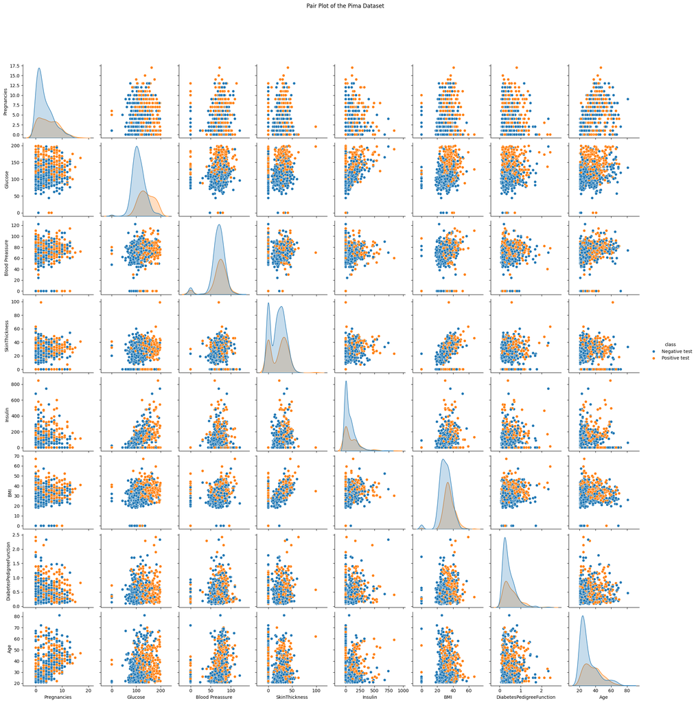

```python
## Before
# View the relationships between variables; color code by species type
di= {0.0: 'Negative test', 1.0: 'Positive test'} # dictionary

before= sns.pairplot(dataframe.replace({'class': di}), hue= 'class')
before.fig.suptitle('Pair Plot of the Pima Dataset', y=1.08)
```

```python
## Definim el train i el test per al model
# split the data into train and test sets
x_train, x_test, y_train, y_test= train_test_split(X, y, test_size= 0.2, shuffle= True, random_state= 0)
x_train_pima= np.asarray(x_train)
y_train_pima= np.asarray(y_train)

x_test_pima= np.asarray(x_test)
y_test_pima= np.asarray(y_test)
```

```python
print(f'training set size: {x_train.shape[0]} samples \ntest set size: {x_test.shape[0]} samples')
```

```
training set size: 613 samples
test set size: 154 samples
```

### Normalitzar

En el context del dataset Pima Indians Diabetes, hauriem de buscar la normalització més adequada i comprovar si és necessària, degut a que les característiques estan a diferents escales i unitats. Apliqueu-ne una

```python
scaler = Normalizer().fit(x_train_pima)
scaler.fit(x_train_pima)
normalized_x_train_pima= scaler.transform(x_train_pima) # the scaler is applied to the training set
normalized_x_test_pima= scaler.transform(x_test_pima) # the scaler is applied to the test set
```

```python
k=9

knn_pima = KNeighborsClassifier(k)

#ajustar model
knn_pima.fit(normalized_x_train_pima, y_train_pima)

#predicció
y_pred_pima = knn_pima.predict(normalized_x_test_pima)

#calcular accuracy
acc = accuracy_score(y_test_pima, y_pred_pima)

print(f'The accuracy of sklearn implementation is {acc}')
```

```
The accuracy of sklearn implementation is 0.7402597402597403
```

Com hem pogut observar, la normalització de dades és un pas important, però no sempre és necessària. En el cas del dataset Iris, hem vist que aquest preprocessament és crucial, mentre que, per al dataset Pima, no ho és tant. Existeixen diverses estratègies per normalitzar les dades, com el Min-Max Scaler o el Standard Scaler, però no totes són igual d'efectives per a qualsevol conjunt de dades. Algunes tècniques ofereixen millors resultats en determinades situacions que en d'altres. Investiga les principals maneres de normalitzar les dades i explica en quins casos són més adequades unes estratègies en comparació amb altres.

**Resposta:**

### Confusion Matrix

Una matriu de confusió és una taula resumida que s'utilitza per avaluar el rendiment d'un model de classificació.

El accuracy pot ser enganyosa si s'utilitza amb conjunts de dades desequilibrats, i, per tant, hi ha altres mètriques basades en la matriu de confusió que poden ser útils per avaluar el rendiment.

[figure not shown]

En aquest cas, una de les mètriques més importants en temes de classificació binaria és el **F-score**, que et parla de la relació entre la **precissió** i el **recall**, dues mètriques molt importants. Per tant, en tasques de classificació equilibrades (on una de les mètriques no sigui més important que l'altra) és important utilitzar aquesta mètrica.

$$ F_{1} = \frac{2 \cdot \text{Precisión} \cdot \text{Recall}}{\text{Precisión} + \text{Recall}} $$

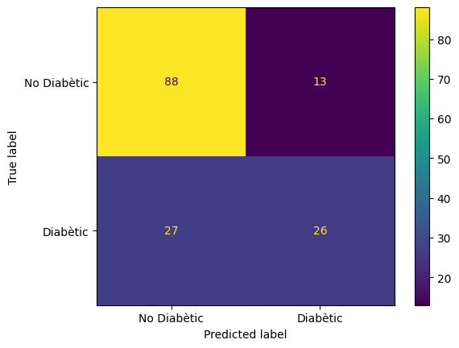

```python
from sklearn.metrics import ConfusionMatrixDisplay

cm = confusion_matrix(y_test_pima, y_pred_pima)
disp = ConfusionMatrixDisplay(confusion_matrix=cm, display_labels=["No Diabètic","Diabètic"])
disp.plot()
plt.show()
```

**Volem calcular la *Precision* i el *Recall*:**

- Precision: És la proporció de veritables positius (TP) entre tots els exemples predits com a positius, és a dir, mesura quantes de les prediccions positives són correctes.
- Recall: És la proporció de veritables positius (TP) entre tots els exemples que són realment positius, és a dir, mesura quants dels positius reals són correctament identificats.

```python
precision = precision_score(y_test_pima, y_pred_pima)
recall = recall_score(y_test_pima, y_pred_pima)
print(f"Precision: {precision} \nRecall: {recall}")
```

```
Precision: 0.6666666666666666
Recall: 0.49056603773584906
```

Programeu una classe per generar una matriu de confusió (TP, FP, TN, FN) i implementeu diverses funcions que permetin calcular les principals mètriques derivades d'aquesta matriu: precisió (precision), sensibilitat (recall), especificitat (specificity) i la mesura F1 (F-score)

```python
class Confusion_Matrix(object):


    def __init__(self, y_pred :list, gt:list):
        assert len(y_pred) == len(gt), "Les prediccions i el gt tenen shapes diferents"
        self._y_pred = y_pred
        self._gt = gt

        self.get_confusion()


    def get_confusion(self):
        self._tp = (self._y_pred ==1 and self._gt ==1).sum()
        self._fp = (self._y_pred ==1 and self._gt ==0).sum()
        self._fn = (self._y_pred ==0 and self._gt ==1).sum()
        self._tn = (self._y_pred ==0 and self._gt ==0).sum()


    def accuracy(self):
        return (self._tp + self._tn)/(self._tp + self._tn + self._fp + self._fn)

    def precision(self):
        return self._tp/(self._tp + self._fp)

    def recall(self):
        return self._tp/(self._tp + self._fn)

    def specificity(self):
        return self._tn/(self._tn + self._fp)

    def f_score(self):
        return 2*(self.precision()*self.recall())/(self.precision() + self.recall())
```

### ROC curve

La ROC curve (Receiver Operating Characteristic curve) i la PR curve (Precision-Recall curve) són eines gràfiques utilitzades per avaluar el rendiment d'un model de classificació, especialment en situacions de classificació binària . Tot i que les dues corbes serveixen per mesurar la qualitat del model, s'enfoquen en diferents aspectes del mateix.

Una corba ROC ideal s'aproxima al vèrtex superior esquerre del gràfic, cosa que indica una alta taxa de veritables positius i una baixa taxa de falsos positius. L'Àrea Sota la Corba ROC (AUC-ROC) és una mètrica comuna derivada de la corba. Un valor d'AUC proper a 1 indica un model excel·lent, mentre que un valor proper a 0.5 suggereix un model que no és millor que endevinar l'atzar.

- Eix X: Taxa de Falsos Positius (False Positive Rate, FPR) = FP/(FP+TN). Representa el percentatge de vegades que el model prediu incorrectament una classe positiva quan en realitat era negativa.
- Eix Y: Taxa de Veritables Positius (True Positive Rate, TPR) o Sensibilitat (Recall) = TP / (TP + FN). Representa el percentatge de vegades que el model prediu correctament la classe positiva quan realment és positiva.

[figure not shown]

```python
from sklearn.metrics import roc_curve, RocCurveDisplay, auc
y_pred = knn_pima.predict(normalized_x_test_pima)
y_pred_prob = knn_pima.predict_proba(normalized_x_test_pima)
for pred, prob in zip(y_pred[:6], y_pred_prob[:6]):
    print(f"{pred}    {prob}")
```

```
0.0    [0.55555556 0.44444444]
0.0    [0.66666667 0.33333333]
1.0    [0.44444444 0.55555556]
0.0    [0.77777778 0.22222222]
0.0    [0.66666667 0.33333333]
0.0    [0.77777778 0.22222222]
```

El mètode *predict_proba* a l'algorisme K-Nearest Neighbors (KNN) permet obtenir probabilitats de classificació en lloc de prediccions directes de classe.

Exemple: Suposem que estem classificant una nova instància amb k = 5, i els veïns més propers estan distribuïts de la següent manera:

- 3 veïns pertanyen a la classe positiva (1).
- 2 veïns pertanyen a la classe negativa (0). En aquest cas, la probabilitat que la instància pertanyi a la classe positiva (1) seria:

$$ P(\text{classe positiva}) = \frac{3}{5} = 0.6 $$ Y la probabilitat de que pertanyi a la classe negativa (0) seria:

$$ P(\text{classe negativa}) = \frac{2}{5} = 0.4 $$

Nosaltres utilitzarem el segon valor de cada element com a threshold, el qual reflecteix la probabilitat que una persona tingui diabetis.

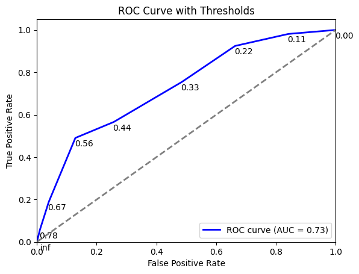

```python
fpr, tpr, thresholds = roc_curve(y_test_pima, y_pred_prob[:,1])
roc_auc = auc(fpr, tpr)

plt.figure()
plt.plot(fpr, tpr, color='blue', lw=2, label=f'ROC curve (AUC = {roc_auc:.2f})')
plt.plot([0, 1], [0, 1], color='gray', lw=2, linestyle='--')

for i, threshold in enumerate(thresholds):
    plt.annotate(f'{threshold:.2f}', (fpr[i], tpr[i]), textcoords="offset points", xytext=(10,-10), ha='center')

plt.xlim([0.0, 1.0])
plt.ylim([0.0, 1.05])
plt.xlabel('False Positive Rate')
plt.ylabel('True Positive Rate')
plt.title('ROC Curve with Thresholds')
plt.legend(loc="lower right")
plt.show()
```

**Quines conclusions podem treure amb aquesta gràfica? Quin és el threshold òptim?**

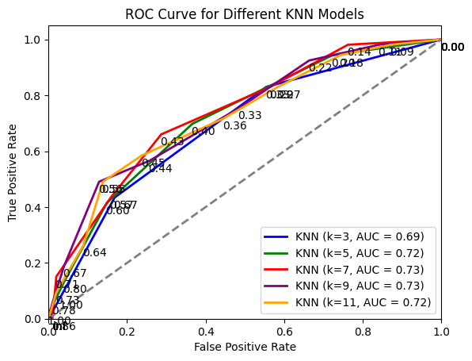

```python
# Valores de k a utilitzar
k_values = [3, 5, 7, 9, 11]
plt.figure()

colors = ['blue', 'green', 'red', 'purple', 'orange']
roc_auc = []

# Entrenar y calcular la corba ROC per cada valor de k
for i, k in enumerate(k_values):
    # Definir el model
    knn_pima = KNeighborsClassifier(k)
    knn_pima.fit(normalized_x_train_pima, y_train_pima)

    # Predir las probabilitats
    y_pred_prob = knn_pima.predict_proba(normalized_x_test_pima)

    # Calcular la corba ROC i el AUC
    fpr, tpr, thresholds = roc_curve(y_test_pima, y_pred_prob[:,1])
    roc_auc.append(auc(fpr, tpr))

    # Graficar la corba ROC
    plt.plot(fpr, tpr, color=colors[i], lw=2, label=f'KNN (k={k}, AUC = {roc_auc[-1]:.2f})')

    for j, threshold in enumerate(thresholds):
        plt.annotate(f'{threshold:.2f}', (fpr[j], tpr[j]), textcoords="offset points", xytext=(10,-10), ha='center')

plt.plot([0, 1], [0, 1], color='gray', lw=2, linestyle='--')
plt.xlim([0.0, 1.0])
plt.ylim([0.0, 1.05])
plt.xlabel('False Positive Rate')
plt.ylabel('True Positive Rate')
plt.title('ROC Curve for Different KNN Models')
plt.legend(loc="lower right")
plt.show()
```

#### Hi ha maneres de calcular el millor threshold. Un exemple és la G-mean i la J-statistic.

[figure not shown]

```python
def J_statistic(y_true:list, y_score:list):
    fpr, tpr, thresholds = roc_curve(y_true, y_score)
    # get the best threshold
    J = tpr - fpr
    ix = np.argmax(J)
    best_thresh = thresholds[ix]
    print('Best Threshold=%f' % (best_thresh))

        # plot the roc curve for the model
    plt.plot([0,1], [0,1], linestyle='--', label='No Skill')
    plt.plot(fpr, tpr, marker='.', label='Logistic')
    plt.scatter(fpr[ix], tpr[ix], marker='o', color='black', label='Best')
    # axis labels
    plt.xlabel('False Positive Rate')
    plt.ylabel('True Positive Rate')
    plt.legend()
    # show the plot
    plt.show()
    return best_thresh
```

```
Best Threshold=0.545455
```

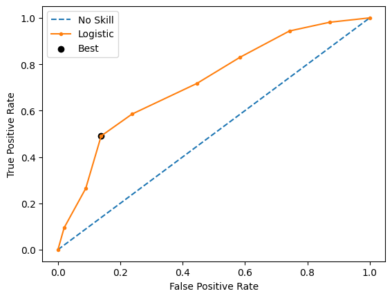

```
0.5454545454545454
```

```python
J_statistic(y_test_pima, y_pred_prob[:,1])
```

### K-Fold Cross Validation

La validació creuada o cross-validation és una tècnica utilitzada per a avaluar els resultats d'una anàlisi estadística i garantir que són independents de la partició entre dades d'entrenament i prova. Consisteix a repetir i calcular la mitjana aritmètica obtinguda de les mesures d'avaluació sobre diferents particions.

El mètode K-Fold Cross-Validation és també un procés iteratiu. Consisteix a dividir les dades de manera aleatòria en k grups d'aproximadament la mateixa grandària, k-1 grups s'empren per a entrenar el model i un dels grups s'empra com a validació. Aquest procés es repeteix k vegades utilitzant un grup diferent com a validació en cada iteració. El procés genera k estimacions de l'error la mitjana del qual s'empra com a estimació final.

Dos avantatges del mètode K-Fold Cross-Validation enfront del LOOCV:

Requeriments computacionals: el nombre d'iteracions necessàries ve determinat pel valor k triat. En general, es recomana un k entre 5 i 10.

Balanç entre bias i variància: el principal avantatge de K-fold CV és que aconsegueix una estimació precisa de l'error de test gràcies a un millor balanç entre bias i variància. LOOCV empra n-1 observacions per a entrenar el model, la qual cosa és pràcticament tot el set de dades disponible, maximitzant així l'ajust del model a les dades disponibles i reduint el bias. No obstant això, per a l'estimació final de l'error es fan una mitjana de les estimacions de n models entrenats amb pràcticament les mateixes dades (només hi ha una dada de diferència entre cada conjunt d'entrenament), per la qual cosa estan altament correlacionats. Això es tradueix en un major risc de overfitting i per tant de variància. En el mètode K-fold CV els k grups emprats com a entrenament són molt menys solapants, la qual cosa es tradueix en menor variància en fer una mitjana de les estimacions d'error.

[figure not shown]

```python
from sklearn.model_selection import cross_val_score,cross_validate

dataframe = read_csv("pima-indians-diabetes.csv", header=0, names=["Pregnancies", "Glucose", "Blood Preassure", "SkinThickness","Insulin", "BMI", "DiabetesPedigreeFunction","Age", "class"])
values = dataframe.values
X, y = values[:, :-1], values[:, -1]


clf = KNeighborsClassifier(n_neighbors=3)
scores = cross_val_score(clf, X, y, cv=3)
scoring = ['accuracy', 'precision_macro', 'recall_macro']
cvs = cross_validate(clf, X, y, cv=3, scoring=scoring, return_estimator=True, return_indices=False)
```

```python
cvs
```

```
{'fit_time': array([0.0009985 , 0.00100088, 0.0010004 ]),
 'score_time': array([0.01965261, 0.01805615, 0.01873446]),
 'estimator': [KNeighborsClassifier(n_neighbors=3),
  KNeighborsClassifier(n_neighbors=3),
  KNeighborsClassifier(n_neighbors=3)],
 'test_accuracy': array([0.6953125 , 0.69921875, 0.68235294]),
 'test_precision_macro': array([0.6624699 , 0.66394928, 0.6510101 ]),
 'test_recall_macro': array([0.65888448, 0.6461347 , 0.65178692])}
```

```python
dataframe = pd.read_csv("pima-indians-diabetes.csv", header=0, names=["Pregnancies", "Glucose", "Blood Preassure", "SkinThickness","Insulin", "BMI", "DiabetesPedigreeFunction","Age", "class"])
values = dataframe.values
X, y = values[:, :-1], values[:, -1]

k_values = [1, 3, 5, 7, 9, 11, 13, 15]

kf = KFold(n_splits=5 , shuffle=True, random_state=42)

scoring = { 'accuracy': 'accuracy', 'precision_macro': 'precision_macro','recall_macro': 'recall_macro'}

results = {metric: {} for metric in scoring}
for k in k_values:
    model = KNeighborsClassifier(n_neighbors=k)
    scores = cross_val_score(model, X, y, cv=kf, scoring='accuracy')
    results['accuracy'][k] = scores.mean()

    precision_scores = cross_val_score(model, X, y, cv=kf, scoring='precision_macro')
    results['precision_macro'][k] = precision_scores.mean()

    recall_scores = cross_val_score(model, X, y, cv=kf, scoring='recall_macro')
    results['recall_macro'][k] = recall_scores.mean()

best_k_accuracy = max(results['accuracy'], key=results['accuracy'].get)
best_k_precision = max(results['precision_macro'], key=results['precision_macro'].get)
best_k_recall = max(results['recall_macro'], key=results['recall_macro'].get)

print(f'El millor valor de K basat en accuracy es {best_k_accuracy} amb una accuracy promig de {results["accuracy"][best_k_accuracy]:.4f}')
print(f'El millor valor de K basat en precisión macro es {best_k_precision} amb una precisión macro promig de {results["precision_macro"][best_k_precision]:.4f}')
print(f'El millor valor de K basat en recall macro es {best_k_recall} amb un recall macro promig de {results["recall_macro"][best_k_recall]:.4f}')
```

```
El millor valor de K basat en accuracy es 13 amb una accuracy promig de 0.7458
El millor valor de K basat en precisión macro es 13 amb una precisión macro promig de 0.7238
El millor valor de K basat en recall macro es 11 amb un recall macro promig de 0.6929
```

## Preguntes teòriques

A continuació, se us presenten tres situacions en què haureu de decidir com balancejar un model de classificació. Reflexioneu sobre la mètrica més adequada a prioritzar en cada cas, tenint en compte les característiques específiques de les dades i l'objectiu del model:

1. Esteu desenvolupant un mètode per detectar càncer de pulmó utilitzant dades privades. La dificultat principal és que disposeu de poques dades, ja que són difícils d'aconseguir. Tot i que voldríeu obtenir una precisió elevada, la disponibilitat limitada de dades us obliga a reconsiderar les vostres prioritats.

2. Teniu un sistema que ha de detectar quins mòbils Apple d'un lot estan defectuosos abans de ser comercialitzats. Suposeu que rebeu un lot de 100 dispositius, però només 10 d'ells funcionen correctament. L'objectiu és seleccionar almenys 5 mòbils que no estiguin defectuosos.

3. Treballeu en un sistema recomanador de YouTube, i el vostre objectiu és recomanar vídeos de la manera més precisa possible, maximitzant el nombre de recomanacions que agradin als usuaris. Voleu oferir contingut rellevant i evitar recomanacions errònies, que puguin desincentivar l'ús de la plataforma.